# Homework Answers

SC19017016

2019/12/30

## HW0

Question: (1) Go through “R for Beginners” if you are not familiar with R programming.

2. Use knitr to produce at least 3 examples (texts, figures, tables).

```r
# Directly assign a string of charaters to x
x <- "Hello World!";x
```

```
## [1] "Hello World!"
```

```r
# Use the c() function to connect the two strings
y <-c(x,"Welcome to the RStudio!");y
```

```
## [1] "Hello World!"            "Welcome to the RStudio!"
```

```r
# Display the properties of x
mode(x)
```

```
## [1] "character"
```

```r
# Dispaly the length of y
length(y)
```

```
## [1] 2
```

```r
# Directly assign number to x1
x1 <- 10
# Use the seq() function to generate a sequence of regular numbers
y1 <- seq(1,10,by=1)
# generate a matrix
z <- matrix(1:9,nrow = 3,ncol = 3)
# Display x1,y1 and z
x1;y1;z
```

```
## [1] 10
```

```
##  [1]  1  2  3  4  5  6  7  8  9 10
```

```
##      [,1] [,2] [,3]
## [1,]    1    4    7
## [2,]    2    5    8
## [3,]    3    6    9
```

```r
# Determine whether z is a array
is.array(z)
```

```
## [1] TRUE
```

```r
# Generate the informations of ID,Age and Score.
ID<-seq(19017001,19017040,by=1)
Age<-floor(rnorm(40,mean = 23,sd=1))
Score<-floor(rnorm(40,mean=80,sd=10))
my_table<-data.frame(ID,Age,Score);my_table
```

```
##          ID Age Score
## 1  19017001  21    91
## 2  19017002  20    74
## 3  19017003  23    78
## 4  19017004  22    78
## 5  19017005  20    86
## 6  19017006  22    99
## 7  19017007  22    85
## 8  19017008  22    73
## 9  19017009  23    89
## 10 19017010  21    98
## 11 19017011  23    89
## 12 19017012  22    87
## 13 19017013  22    68
## 14 19017014  24    98
```

[output cut: 26 more lines]

## HW1

Question: (1) The Rayleigh density:$f(x)=\frac{x}{\sigma^{2}} e^{-x^{2} /\left(2 \sigma^{2}\right)}, \quad x \geq 0, \sigma>0$. Develop an algorithm to generate random samples from a Rayleigh $(\sigma)$ distribution. Generate Rayleigh ($\sigma$ ) samples for several choices of $\sigma>0$ and check that the mode of the generated samples is close to the theoretical mode $\sigma$(check the histogram).

2. Generate a random sample of size 1000 from a normal location mixture. The components of the mixture have $N(0,1)$ and $N(3,1)$ distributions with mixing probabilities $p_{1}$ and $p_{2}=1-p_{1}$ . Graph the histogram of the sample with density superimposed, for $p_{1}=0.75 .$ Repeat with different values for $p_{1}$ and observe whether the empirical distribution of the mixture appears to be bimodal. Make a conjecture about the values of $p_{1}$ that produce bimodal mixtures.
3. Write a function to generate a random sample from a $W_{d}(\Sigma, n)$(Wishart) distribution for $n>d+1 \geq 1,$ based on Bartlett’s decomposition.

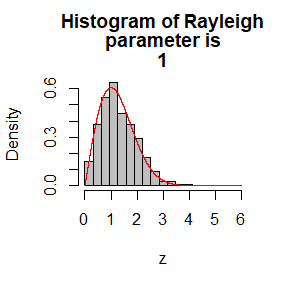

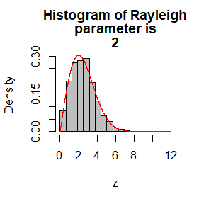

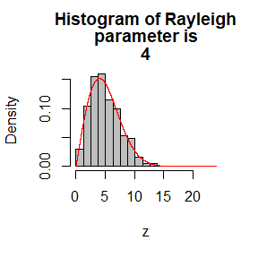

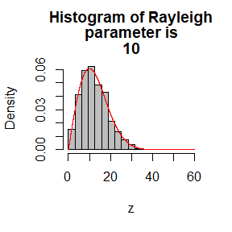

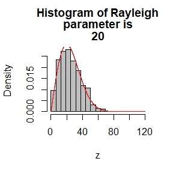

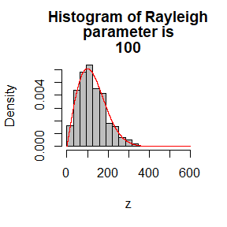

```r
# generate a collection of Sigma
sigma<-c(1,2,4,10,20,100)
# set the format of output picture
# use circular structure to generate the random numbers in different parameter
for (i in 1:length(sigma)) {
  # set the seed to guarantee the consistency of Pseudo-Random numbers
  set.seed(i)
  # the title of histogram
  title<-c("Histogram of Rayleigh","parameter is",sigma[i])
  # generate the random numbers of normal distribution
  x<-rnorm(1000,0,sigma[i])
  y<-rnorm(1000,0,sigma[i])
  # generate the random numbers of Rayleigh distribution
  z<-sqrt(x^2+y^2)
  #diagram the histogram and check it
  hist(z,prob=TRUE,breaks = seq(0,6*sigma[i],length.out = 20)
       ,main = title,col = "grey")
  # plot the Rayleigh density function
  x1<-seq(0,6*sigma[i],length.out = 100000)
  y1<-(x1/sigma[i]^2)*exp(-(x1^2)/(2*sigma[i]^2))
  lines(x1,y1,col="red")
}
```

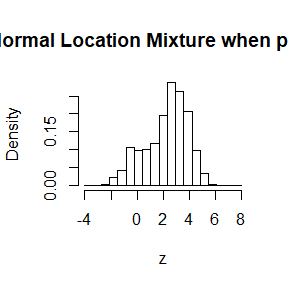

```r
# set the size
size<-1000
#generate the normal random numbers
x<-rnorm(size,0,1)
y<-rnorm(size,3,1)
# when the p=0.75
r<-sample(c(0,1),size,replace = TRUE,prob = c(0.75,0.25))
# generate the normal location mixture
z<-r*x+(1-r)*y
# diagram the histogram of z
hist(z,prob=TRUE,breaks = seq(-4,8,length.out = 20),main = "Normal Location Mixture when p=0.75")
```

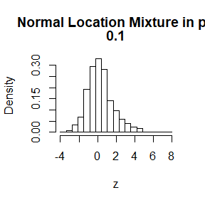

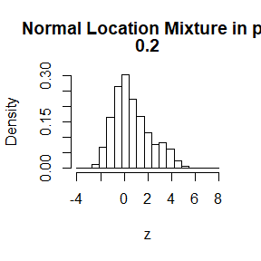

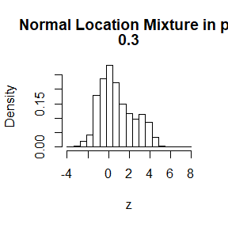

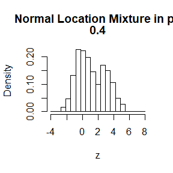

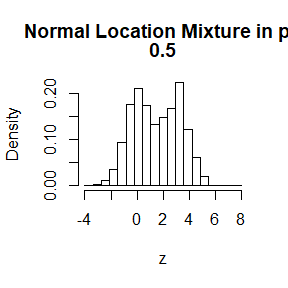

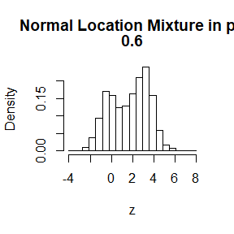

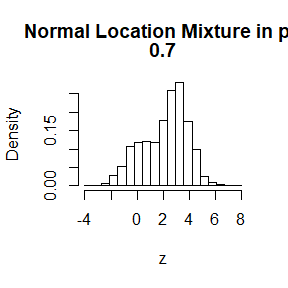

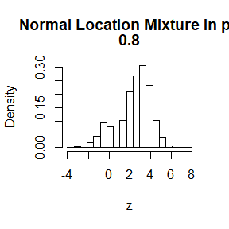

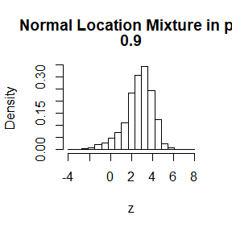

```r
p<-seq(0.1,0.9,by=0.1)
# set the format
for (i in 1:length(p)) {
  # set the seed to guarantee the consistency of Pseudo-Random numbers
  set.seed(i)
  # generate the random numbers which respectively subjects to the Normal         distribution
  x<-rnorm(size,0,1)
  y<-rnorm(size,3,1)
  # set the title of histogram
  title<-c("Normal Location Mixture in p=",p[i])
  # generate the p
  r<-sample(c(0,1),size,replace = TRUE,prob = c(p[i],1-p[i]))
  # generate the normal location mixture
  z<-r*x+(1-r)*y
  # plot the histogram
  hist(z,prob=TRUE,breaks = seq(-4,8,length.out = 20),main = title)
}
```

```r
# function of Wishart
Wishart<-
  function(sigma,n){
    # choleski decomposition of sigma
    Q<-chol(sigma)
    # dimension of sigma
    d<-sqrt(length(sigma))
    # generate the Bartlett's decomposition matrix
    # generate the zero matrix which will be used to save the value
    # t is the lower triangular d*d random matrix
    t<-matrix(numeric(d*d),nrow = d,ncol = d)
    for (i in 1:d) {
      j<-1
      while(j<i){
        # T(i,j) should be sample from standard normal distribution
        t[i,j]<-rnorm(1,mean = 0,sd =1)
        # lower triangular matrix
        j<-j+1
      }
      # T(i,i) should be a random number from chi-squared distribution
      t[i,i]<-rchisq(1,n-i+1)
    }
    # accroding to the formula,calculate the matrix which subject to tht           Wishart distribution
    A<-t%*%t(t)
    x<-Q%*%A%*%t(Q)
    # display x
    x
  }
```

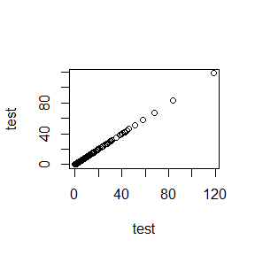

```r
# generate the empty set to save the value
test<-numeric(1000)
# generate random numbers subject to Wishart distribution
for (i in 1:1000) {
  temp<-Wishart(1,1)
  test[i]<-temp
}
# generate random numbers subject to Chi-square distribution
test2<-rchisq(1000,1)
# plot QQ-plot
qqplot(test,test)
```

## HW2

Question: (1) Compute a Monte Carlo estimate of $\int_{0}^{\pi / 3} \sin t d t$ and compare your estimate with the exact value of the integral.

2. Use Monte Carlo integration with antithetic variables to estimate $\int_{0}^{1} \frac{e^{x}}{1+x^{2}} d x$ and find the approximate reduction in variance as a percentage of the variance without variance reduction.
3. Obtain the stratified importance sampling estimate in Example 5.13 and compare it with the result of Example 5.10.

```r
m<-1e4
## save the theta.hat
theta.hat=numeric(3)
## method one
set.seed(12345)
T<-runif(m,min = 0,max = pi/3)
## define g(x)
g1<-function(t){
  (3/pi)*sin(t)
}
## MC method
theta.hat[1]<-mean(g1(T))
## method two
set.seed(12345)
X<-runif(m,0,1)
## define g(x)
g2<-function(x){
  (pi/3)*sin((pi*x)/3)
}
theta.hat[2]<-mean(g2(X))
## exact value
theta.hat[3]<-0.5
## show the theta.hat
theta.hat
```

```
## [1] 0.4567774 0.5009124 0.5000000
```

```r
## Monte carlo Antithetic Variables
m<-10000
## save the theta.hat and variance
theta.hat<-numeric(2)
Var_thata.hat<-numeric(2)
temp_u<-runif(m/2,0,1)
## generate the antithetic variables
v<-1-temp_u
u1<-c(temp_u,v)
## define g(x)
g<-function(x){
  exp(x)/(1+x^2)
}
theta.hat[1]<-mean(g(u1))
## calculate the variance
Var_thata.hat[1]<-var(g(u1))
## without variance reduction
u2<-runif(m,0,1)
theta.hat[2]<-mean(g(u2))
Var_thata.hat[2]<-var(g(u2))
# show the theta.hat and variance
theta.hat
```

```
## [1] 1.270542 1.271222
```

```r
Var_thata.hat
```

```
## [1] 0.01069954 0.01053559
```

```r
## percentage of the variance without variance reduction.
(Var_thata.hat[1]-Var_thata.hat[2])/Var_thata.hat[2]
```

```
## [1] 0.01556132
```

```r
m<-10000
## save the value
theta.hat<-numeric(2)
Var_thata.hat<-numeric(2)
## define the function
g<-function(x){
  exp(-x)/(1+x^2)*(x>0)*(x<1)
}
## the importance sampling
set.seed(12345)
u<-runif(m,0,1)
x<--log(1-u*(1-exp(-1)))
fg<-g(x)/(exp(-x)/(1-exp(-1)))
theta.hat[1]<-mean(fg)
Var_thata.hat[1]<-sd(fg)
## the Stratified importance sampling
## the number of grouop
j<-5
## the samples of every group
r<-m/j
##save the value
theta_j<-numeric(j)
var_theta1<-numeric(j)
sub_interval<-c(0,0.1351603,0.291487,0.4768629,0.7046056,1)
for (i in 1:5) {
  set.seed(i)
  # in the subinterval,we generate the random number
  u<-runif(r,min =sub_interval[i],max=sub_interval[i+1])
  # inverse transformation
  x<--log(exp(-sub_interval[i])-u/5*(1-exp(-1)))
  # assignment theta_j
  theta_j[i]<-mean(g(x)/(5*exp(-x)/(1-exp(-1))))
  # calculate the variance
  var_theta1[i]<-var(g(x)/(5*exp(-x)/(1-exp(-1))))
}
theta.hat[2]<-sum(theta_j)
Var_thata.hat[2]<-sum(var_theta1)
# show the theta and variance
theta.hat
```

```
## [1] 0.5248663 0.5203768
```

```r
Var_thata.hat
```

```
## [1] 9.627381e-02 5.560915e-06
```

## HW3

Question: (1) Suppose a 95% symmetric t-interval is applied to estimate a mean, but the sample data are non-normal. Then the probability that the confidence interval covers the mean is not necessarily equal to 0.95. Use a Monte Carlo experiment to estimate the coverage probability of the t-interval for random samples of $\chi^{2}(2)$ data with sample size n = 20. Compare your t-interval results with the simulation results in Example 6.4. (The t-interval should be more robust to departures from normality than the interval for variance.)

2. Estimate the 0.025, 0.05, 0.95, and 0.975 quantiles of the skewness $\sqrt{b_{1}}$ undernormality by a Monte Carlo experiment. Compute the standard error of the estimates from (2.14) using the normal approximation for the density (with exact variance formula). Compare the estimated quantiles with the quantiles of the large sample approximation $\sqrt{b_{1}} \approx N(0,6 / n)$

```r
#number of replicate
m<-1e4
# number of samples
n<-20
# confidence level
alpha<-0.05
# define the CI of Student's T-distribution to estimate the mean
# when x subject to the Normal-distribution
t_CI_N<-function(n,alpha){
  x<-rnorm(n,mean = 0,sd=2)
  ci<-matrix(c(mean(x)-qt(1-alpha/2,n-1)*sqrt(var(x)/n),mean(x)+qt(1-alpha/2,n-1)*sqrt(var(x)/n)),nrow = 1,ncol = 2)
}
# define the CI of Student's T-distribution to estimate the mean
# when x subject to the Chi-square-distribution
t_CI_chisq<-function(n,alpha){
  x<-rchisq(n,2)
  ci<-matrix(c(mean(x)-qt(1-alpha/2,n-1)*sqrt(var(x)/n),mean(x)+qt(1-alpha/2,n-1)*sqrt(var(x)/n)),nrow = 1,ncol = 2)
}
# define the CI of Chi-square to estimate the variance
# when x subject to the Normal-distribution
Chisq_CI_N <- function(n, alpha) {
  x <- rnorm(n, mean = 0, sd = 2)
  return((n-1) * var(x) / qchisq(alpha, df = n-1))
}
# define the CI of Chi-square to estimate the variance
# when x subject to the Chi-square distribution
Chisq_CI_chisq <- function(n, alpha) {
  x <- rchisq(n,2)
  return((n-1) * var(x) / qchisq(alpha, df = n-1))
}
# counter
counter1<-0
# generate the CI of mean and evaluate the result
# x subject to the normal distribution
# and Chi-Square distribution repspectively
for (i in 1:m) {
  temp1<-t_CI_N(n,alpha)
  if (temp1[1,1]<0 && temp1[1,2]>0)
    counter1<-counter1+1
}
counter2<-0
for (i in 1:m) {
  temp2<-t_CI_chisq(n,alpha)
  if (temp2[1,1]<2 && temp2[1,2]>2)
    counter2<-counter2+1
}
# generate the CI of variance
# x subject to the normal distribution
# and Chi-Square distribution respectively
CI_CHI_N<-replicate(m,expr = Chisq_CI_N(n,alpha))
CI_CHI_CHI<-replicate(m,expr = Chisq_CI_chisq(n,alpha))
# evaluate the result of variance
r1<-mean(CI_CHI_N > 4)
r2<-mean(CI_CHI_CHI > 4)
# visualize the result
result<-c(counter1/m,counter2/m,r1,r2)
process<-c("CI_mean_X~N","CI_mean_X~ChiS","CI_Var_X~N","CI_Var_X~ChiS")
final_result<-data.frame(process,result)
final_result
```

```
##          process result
## 1    CI_mean_X~N 0.9530
## 2 CI_mean_X~ChiS 0.9209
## 3     CI_Var_X~N 0.9505
## 4  CI_Var_X~ChiS 0.7828
```

```r
# number of replicatioin
m<-1e4
# empty array to save the value
sk<-numeric(m)
# generate the a set of skewness values
library(moments)
for (i in 1:m) {
  x<-rnorm(1e4,mean = 0,sd = 1)
  sk[i]<-skewness(x)
}
# quantiles to be calculated
q<-c(0.025,0.05,0.95,0.975)
quantile_1<-quantile(sk,probs = q)
# calculate the variance of sample quantile
var_sk<-numeric(4)
for (i in 1:4) {
  var_sk[i]<-quantile_1[i]*(1-quantile_1[i])/(m*dnorm(quantile_1[i]))
}
Mark<-c("Var_SK_0.025","Var_SK_0.05","Var_SK_0.95","Var_SK_0.975")
result_var_sk<-data.frame(Mark,var_sk)
result_var_sk
```

```
##           Mark        var_sk
## 1 Var_SK_0.025 -1.270397e-05
## 2  Var_SK_0.05 -1.067060e-05
## 3  Var_SK_0.95  9.921631e-06
## 4 Var_SK_0.975  1.157799e-05
```

## HW4

Question: (1) Estimate the power of the skewness test of normality against symmetric $\operatorname{Beta}(\alpha, \alpha)$ distributions and comment on the results. Are the results different for heavy-tailed symmetric alternatives such as $t(\nu)$?

2. Use Monte Carlo simulation to investigate whether the empirical Type I error rate of the t-test is approximately equal to the nominal significance level $\alpha$, when the sampled population is non-normal. The t-test is robust to mild departures from normality. Discuss the simulation results for the cases where the sampled population is (i)$\chi^{2}(1)$,
   2. Uniform(0,2), and
   3. Exponential(rate=1). In each case, test $H_{0}: \mu=\mu_{0}$ vs $H_{0}: \mu \neq \mu_{0}$, where $\mu_{0}$ is the mean of $\chi^{2}(1)$, Uniform(0,2), and Exponential(1), respectively

```r
# significance level
alpha<-0.05
#number of replicates
m<-1e5
# storage of skewness
sk_1<-sk_2<-numeric(m)
sk_beta<-function(beta,n){
  x<-rbeta(n,beta,beta)
  xbar<-mean(x)
  m3 <- mean((x-xbar)^3)
  m2 <- mean((x-xbar)^2)
  return(m3/m2^1.5)
}

# parameter of Beta distribution
para_beta<-10
# number of sample
n<-30
#critical value for the skewness test
cv <- qnorm(1-alpha/2, 0, sqrt(6*(n-2) / ((n+1)*(n+3))))
# Monte Carlo
for (i in 1:m) {
  temp<-sk_beta(para_beta,n)
  if(abs(temp)>cv)
    sk_1[i]<-1
}
power_beta<-mean(sk_1)


# when the distribution is T-stribution
sk_t<-function(n,d){
  x<-rt(n,d)
  xbar<-mean(x)
  m3 <- mean((x-xbar)^3)
  m2 <- mean((x-xbar)^2)
  return(m3/m2^1.5)
}
# free degree of T-distribution
para_t<-3
for (i in 1:m) {
  temp<-sk_t(n,para_t)
  if(abs(temp)>cv)
    sk_2[i]<-1
}
power_t<-mean(sk_2)
distribution<-c("power_beta","power_t")
power<-c(power_beta,power_t)
result<-data.frame(distribution,power)
result
```

```
##   distribution   power
## 1   power_beta 0.02905
## 2      power_t 0.43008
```

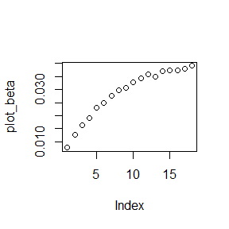

```r
# draw the scatter plot
new_beta<-c(seq(3,20,1))
new_t<-c(seq(1,20,1))
# set parameter
plot_beta<-numeric(length(new_beta))
plot_t<-numeric(length(new_t))
# generate power of beta
for (i in 1:length(new_beta)) {
  storage<-numeric(m)
  for (j in 1:m) {
      temp<-sk_beta(new_beta[i],n)
  if(abs(temp)>cv)
      storage[j]<-1
  }
  plot_beta[i]<-mean(storage)
}
# generate power of T
for (i in 1:length(new_t)) {
  storage<-numeric(m)
  for (j in 1:m) {
      temp<-sk_t(n,new_t[i])
  if(abs(temp)>cv)
      storage[j]<-1
  }
  plot_t[i]<-mean(storage)
}

plot(plot_beta)
```

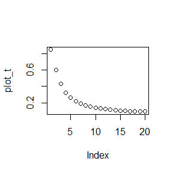

```r
plot(plot_t)
```

```r
# number of replicates
m<-1e4
# significance level
alpha<-0.05
# number of sample
n<-30
# the null hypothesis is true
mu0<-1

# function to calculate the empirical Type I error rate

chi<-function(n,m){
  # MC method
  result<-numeric(m)
for (i in 1:m){
  x<-rchisq(n,1)
  t_test <- t.test(x, alternative = "two.sided", mu = mu0)
  # reject H0 if p<significant level alpha
  if(t_test$p.value<alpha)
    result[i]<-1
}
    return(mean(result))

}

uniform<-function(n,m){
  # MC method
  result<-numeric(m)
for (i in 1:m){
  x<-runif(n,0,2)
  t_test <- t.test(x, alternative = "two.sided", mu = mu0)
  # reject H0 if p<significant level alpha
  if(t_test$p.value<alpha)
    result[i]<-1
}
  return(mean(result))
}

exp<-function(n,m){
  # MC method
  result<-numeric(m)
for (i in 1:m){
  x<-rexp(n,1)
  t_test <- t.test(x, alternative = "two.sided", mu = mu0)
  # reject H0 if p<significant level alpha
  if(t_test$p.value<alpha)
    result[i]<-1
}
  return(mean(result))
}

# calling function
k<-100
temp_r1<-temp_r2<-temp_r3<-numeric(k)
# MC method
for (i in 1:k) {
  temp_r1[i]<-chi(n,m)
  temp_r2[i]<-uniform(n,m)
  temp_r3[i]<-exp(n,m)

}

# Type I error rate
r1<-mean(temp_r1)
r2<-mean(temp_r2)
r3<-mean(temp_r3)
# standard deviation
sd1<-sd(temp_r1)
sd2<-sd(temp_r2)
sd3<-sd(temp_r3)
Type_I_error<-c(r1,r2,r3)
sd_Type_I_error<-c(sd1,sd2,sd3)
Three_Distribution<-c("Chisq","Uniform","Exp")
MC_result<-data.frame(Three_Distribution,Type_I_error,sd_Type_I_error)
MC_result
```

```
##   Three_Distribution Type_I_error sd_Type_I_error
## 1              Chisq     0.092186     0.002777253
## 2            Uniform     0.050425     0.001898770
## 3                Exp     0.073112     0.002640144
```

## HW5

Question: (1) Efron and Tibshirani discuss the scor (bootstrap) test score data on 88 students who took examinations in five subjects [84, Table 7.1], [188, Table 1.2.1].The first two tests (mechanics, vectors) were closed book and the last three tests (algebra, analysis, statistics) were open book. Each row of the data frame is a set of scores $\left(x_{i 1}, \ldots, x_{i 5}\right)$ for the $i^{t h}$ student. Use a panel display to display the scatter plots for each pair of test scores. Compare the plot with the sample correlation matrix. Obtain bootstrap estimates of the standard errors for each of the following estimates: $\hat{\rho}_{12}=\hat{\rho}(\operatorname{mec}, \text { vec }), \hat{\rho}_{34}=\hat{\rho}($ algana),$\hat{\rho}_{35}=\hat{\rho}(\mathrm{alg}, \text { sta }), \hat{\rho}_{45}=\hat{\rho}(\mathrm{ana}, \mathrm{sta})$

2. Repeat Project 7.A for the sample skewness statistic. Compare the coverage rates for normal populations (skewness 0) and $\chi^{2}(5)$ distributions (positive skewness)

```r
# library the package
library(corrplot)
# load data
data(scor,package = "bootstrap")
# draw the scatter plot
plot(scor)
# correlation matrix
M<-cor(scor)
M
```

[output not shown]

```r
# use the Bootstrap to estimate the standard errors
mydata<-scor
B<-1e4
n<-40
# method 1 with the function-sample
rho<-function(i,j){
  mycorr<-numeric(B)
  for (b in 1:B) {
    temp<-sample(1:nrow(scor),nrow(scor),replace = TRUE)
    x<-scor[temp,i]
    y<-scor[temp,j]
    mycorr[b]<-cor(x,y)
  }
  return(sd(mycorr))
}

# method 2 with the package boot
f<-function(x,i){
  cor(x[i,1],x[i,2])
}
d12<-scor[,1:2]
d34<-scor[,3:4]
d35<-matrix(c(scor[,3],scor[,5]),ncol = 2,nrow = nrow(scor))
d45<-scor[,4:5]
# ues bootstrap generate data
r12<-boot(data=d12,statistic=f,R=B)
r34<-boot(data=d34,statistic=f,R=B)
r35<-boot(data=d35,statistic=f,R=B)
r45<-boot(data=d45,statistic=f,R=B)
nr12<-r12$t
nr34<-r34$t
nr35<-r35$t
nr45<-r45$t
result_2<-c(sd(nr12),sd(nr34),sd(nr35),sd(nr45))

# generate the rho
subscript<-matrix(c(1,3,3,4,2,4,5,5),nrow = 4,ncol = 2)
result_1<-numeric(4)
for (i in 1:4) {
  result_1[i]<-rho(subscript[i,1],subscript[i,2])
}
# show the result
Method_1<-c("se_rho_12","se_rho_34","se_rho_35","se_rho_45")
Method_2<-c("se_rho_12","se_rho_34","se_rho_35","se_rho_45")
data.frame(Method_1,result_1,Method_2,result_2)
```

[output not shown]

```r
# library pacage
library(moments)

# simulation times of MC
m<-100
# times of Bootstrap
B<-100
# number of sample
n<-50
# function of skewness
sk<-function(x,i){
  skewness(x[i])
}
ci.basic_N<-ci.perc_N<-matrix(NA,m,2)
# loop
# calculate the CI of N
for (i in 1:m) {
  temp_data<-rnorm(n,mean = 0,sd=1)
  de<-boot(data=temp_data,statistic=sk,R=B)
  ci<-boot.ci(de,type=c("basic","perc"))
  ci.basic_N[i,]<-ci$basic[4:5]
  ci.perc_N[i,]<-ci$percent[4:5]
}
ci.basic_Chi<-ci.perc_Chi<-matrix(NA,m,2)
# calculate the CI of Chisq
for (i in 1:m) {
  temp_data<-rchisq(n,5)
  de<-boot(data=temp_data,statistic=sk,R=B)
  ci<-boot.ci(de,type=c("basic","perc"))
  ci.basic_Chi[i,]<-ci$basic[4:5]
  ci.perc_Chi[i,]<-ci$percent[4:5]
}
# calculate the coverage rates
r_Normal_Basic<-mean(ci.basic_N[,1]<0 & ci.basic_N[,2]>0)
r_Normal_perc<-mean(ci.perc_N[,1]<0 & ci.perc_N[,2]>0)
r_Chisq_Basic<-mean(ci.basic_Chi[,1]>0)
r_Chisq_perc<-mean(ci.perc_Chi[,1]>0)
# show the result
Lable<-c("r_Normal_Basic","r_Normal_perc","r_Chisq_Basic","r_Chisq_perc")
result<-c(r_Normal_Basic,r_Normal_perc,r_Chisq_Basic,r_Chisq_perc)
final_result_1<-data.frame(Lable,result)
final_result_1

# calculate the miss rate on left and right

r1_N_L<-mean(ci.basic_N[,1]>0)
r1_N_R<-mean(ci.basic_N[,2]<0)
r2_N_L<-mean(ci.perc_N[,1]>0)
r2_N_R<-mean(ci.perc_N[,2]<0)

r1_Chi_L<-mean(ci.basic_Chi[,1]<0)
r2_Chi_L<-mean(ci.perc_Chi[,1]<0)


Lable_2<-c("Normal_SK_LeftMiss_Basic","Normal_SK_RightMiss_Basic","Normal_SK_LeftMiss_perc","Normal_SK_LeftMiss_perc","Chisq_SK_LeftMiss_Basic","Chisq_SK_LeftMiss_Basic")
result_2<-c(r1_N_L,r1_N_R,r2_N_L,r2_N_R,r1_Chi_L,r2_Chi_L)
final_result_2<-data.frame(Lable_2,result_2)
final_result_2
```

[output not shown]

## HW6

Question: (1) Refer to Exercise 7.7. Obtain the jackknife estimates of bias and standard error of ˆθ.

2. In Example 7.18, leave-one-out (n-fold) cross validation was used to select the best fitting model. Repeat the analysis replacing the Log-Log model with a cubic polynomial model. Which of the four models is selected by the cross validation procedure? Which model is selected according to maximum adjusted $R^2$?

```r
# data set
data(scor,package = "bootstrap")
# number of loop
n<-nrow(scor)
# define theta
theta<-function(x){
  return(x[1]/sum(x))
}
# calculate the covariance
sigma<-cov(scor)
e_value<-eigen(sigma)
theta_hat<-theta(e_value$values)
# storage of theta
theta_jk<-numeric(n)
# the loop
for (i in 1:n) {
  new_data<-scor[-i,]
  temp<-cov(new_data)
  evalue_temp<-eigen(temp)
  theta_jk[i]<-theta(evalue_temp$values)
}
# calculate the bias
theta_bias<-(n-1)*(mean(theta_jk)-theta_hat)
# calculate the standard error
theta_sd<-sqrt((n-1)*mean((theta_jk-mean(theta_jk))^2))
# show the result
result<-c(theta_bias,theta_sd)
lable<-c("theta_bias","theta_sd")
data.frame(lable,result)
```

```
##        lable      result
## 1 theta_bias 0.001069139
## 2   theta_sd 0.049552307
```

## HW 7

Question: (1) The Count 5 test for equal variances in Section 6.4 is based on the maximum number of extreme points. Example 6.15 shows that the Count 5 criterion is not applicable for unequal sample sizes. Implement a permutation test for equal variance based on the maximum number of extreme points that applies when sample sizes are not necessarily equal.

2. Power comparison (distance correlation test versus ballcovariance test) Modle1:$Y=x/4+e$ Modle:$Y=X/4\times\ e$ $X \sim N\left(0_{2}, l_{2}\right), e \sim N\left(0_{2}, l_{2}\right)$

```r
# define the cout 5 test function
count5test <- function(x, y) {
X <- x - mean(x)
Y <- y - mean(y)
outx <- sum(X > max(Y)) + sum(X < min(Y))
outy <- sum(Y > max(X)) + sum(Y < min(X))

# return 1 (reject) or 0 (do not reject H0)
return(as.integer(max(c(outx, outy)) > 5))
}
# set the parameters
# the number of tow samples are different
n1<-20
n2<-50
u1<-u2<-0
sigma1<-sigma2<-1
# generate the sample
x<-rnorm(n1,u1,sigma1)
y<-rnorm(n2,u2,sigma2)
z<-c(x,y)
# cycle times
R<-1e4
n<-(n1+n2)/2
pool<-c(1:(n1+n2))
# storage of result
temp_result<-numeric(R)
# loop
for (i in 1:R) {
  k<-sample(pool,size=n,replace = FALSE)
  x<-z[k]
  y<-z[-k]
  temp_result[i]<-count5test(x,y)
}
# show the result
alpha_hat<-mean(temp_result)

# MC method
mm<-1e3
MC_method_result<-numeric(mm)
for (i in 1:mm) {
  xx<-rnorm(n1,u1,sigma1)
  yy<-rnorm(n2,u2,sigma2)
  zz<-c(xx,yy)
  temp_r2<-numeric(R)
  for (j in 1:R) {
  k<-sample(pool,size=n,replace = FALSE)
  nx<-zz[k]
  ny<-zz[-k]
  temp_r2[j]<-count5test(nx,ny)
  }
  MC_method_result[i]<-mean(temp_r2)
}
MC_alpha_hat<-mean(MC_method_result)
lable<-c("permutation for one time","permutation in MC method")
result<-c(alpha_hat,MC_alpha_hat)
data.frame(lable,result)
```

```
##                      lable    result
## 1 permutation for one time 0.0537000
## 2 permutation in MC method 0.0729523
```

## HW8

Question: (1) Implement a random walk Metropolis sampler for generating **the standard Laplace distribution** (see Exercise 3.2). For the increment, simulate from a normal distribution. Compare the chains generated when **different variances** are used for the proposal distribution. Also, compute the acceptance rates of each chain.

```r
# define the function of standard Laplace
dLaplace<-function(x){
  if(x>0) return((1/2)*exp(-x))
  if(x==0) return(1/2)
  if(x<0) return((1/2)*exp(x))
}

# define the random walk function
rw.Metropolis<-function(sigma,x0,N){
  x<-numeric(N)
  x[1]<-x0
  u <- runif(N)
  k<-0
  for (i in 2:N) {
    y<-rnorm(1, x[i-1], sigma)
    if (u[i] <= (dLaplace(y) / dLaplace(x[i-1])))
      x[i] <- y else {
          x[i] <- x[i-1]
          k <- k + 1
      }
  }
  return(list(x=x, k=k))
}
# iteration times
N<-2000
# differnet variance
sigma<-c(0.1,0.25,0.5,1,2,4,16)
# initial position
x0<-0
index<-seq(from=1,to=2000,by=1)
accep_rate<-numeric(length(sigma))
```

[output not shown]

## HW 9

Question: (1) The natural logarithm and exponential functions are inverses of each other, so that mathematically log(exp x) = exp(logx) = x. Show by example that this property does not hold exactly in computer arithmetic. Does the identity hold with near equality? (See all.equal.)

2. Write a function to solve the equation $\frac{2 \Gamma\left(\frac{k}{2}\right)}{\sqrt{\pi(k-1)} \Gamma\left(\frac{k-1}{2}\right)} \int_{0}^{c_{k-1}}\left(1+\frac{u^{2}}{k-1}\right)^{-k / 2} d u$$=\frac{2 \Gamma\left(\frac{k+1}{2}\right)}{\sqrt{\pi k} \Gamma\left(\frac{k}{2}\right)} \int_{0}^{c_{k}}\left(1+\frac{u^{2}}{k}\right)^{-(k+1) / 2} d u$ for where $c_{k}=\sqrt{\frac{a^{2} k}{k+1-a^{2}}}$ Compare the solutions with the points $A(k)$ in Exercise 11.4
3. Let the three alleles be A, B, and O with allele frequencies p, q, and r. The 6 genotype frequencies under HWE and complete counts are as follows. Observed data: nA· = nAA + nAO = 28 (A-type), nB· = nBB + nBO = 24 (B-type), nOO = 41 (O-type), nAB = 70 (AB-type). 1.Use EM algorithm to solve MLE of p and q (consider missing data nAA and nBB). 2.Show that the log-maximum likelihood values in M-steps are increasing via line plot.

```r
# define the sk(a) function
s_k_a<-function(a,k){
  temp<-sqrt(a^2*(k-1)/(k-a^2))
  sk<-1-pt(temp,k-1)
  return(sk)
}
k<-c(seq(from=4,to=25,by=1),100,500,1000)
AK_without_uniroot<-AK_with_uniroot<-numeric(length(k))
# without the 'uniroot'-function
for (j in 1:length(k)) {
  a<-seq(from=0,to=(sqrt(k[j])),by=0.01)
  temp1<-temp2<-numeric(length(a))
  for (i in 1:length(a)) {
    temp1[i]<-s_k_a(a[i],k[j])
    temp2[i]<-s_k_a(a[i],k[j]+1)
  }
  temp<-which.min(abs(temp1[-1]-temp2[-1]))
  AK_without_uniroot[j]<-a[-1][temp]
}
# use the 'uniroot'
for (j in 1:length(k)) {
  ff<-function(a) pt(sqrt(a^2*(k[j]-1)/(k[j]-a^2)),k[j]-1)-pt(sqrt(a^2*(k[j])/(k[j]+1-a^2)),k[j])
  temp<-uniroot(ff,c(0.0001,sqrt(k[j])-0.001))
  AK_with_uniroot[j]<-temp$root
}
# show the result
result<-cbind(AK_without_uniroot,AK_with_uniroot)
result
```

```
##       AK_without_uniroot AK_with_uniroot
##  [1,]               1.49        1.492103
##  [2,]               1.53        1.533547
##  [3,]               1.56        1.562768
##  [4,]               1.58        1.584421
##  [5,]               1.60        1.601192
##  [6,]               3.00        1.614501
##  [7,]               3.16        1.625388
##  [8,]               3.31        1.634390
##  [9,]               3.46        1.641998
## [10,]               3.60        1.648526
## [11,]               3.74        1.654166
## [12,]               3.87        1.659099
## [13,]               4.00        1.663452
## [14,]               4.12        1.667288
## [15,]               4.24        1.670736
## [16,]               4.35        1.673840
## [17,]               4.47        1.676588
## [18,]               4.58        1.679139
## [19,]               4.69        1.681461
## [20,]               4.78        4.794832
## [21,]               4.86        4.897979
## [22,]               4.94        4.999000
## [23,]               6.89        9.999000
## [24,]               7.27       22.359680
## [25,]               7.16       31.621777
```

```r
# set seed
set.seed(543)
# define the parameter
N<-10000
nAO<-nBO<-10
nA<-28
nB<-24
nOO<-41
nAB<-70
n<-nA+nB+nOO+nAB
tol <- .Machine$double.eps^0.5
L.old<-c(0.3,0.4,0.3)
counter<-1
p_pro<-numeric(N)
q_pro<-numeric(N)
# start the EM method without 'mle'-function
for (i in 1:N) {
  lambda1<-(2*(nA-nAO)+nAO+nAB)/(2*(nA-nAO)+2*nOO+2*nAO+nBO+nAB)
  lambda2<-(2*(nB-nBO)+nBO+nAB)/(2*(nB-nBO)+2*nOO+2*nBO+nAO+nAB)
  p<-lambda1*(1-lambda2)/(1-lambda1*lambda2)
  q<-lambda2*(1-lambda1)/(1-lambda1*lambda2)
  nAO<-2*p*(1-p-q)*n
  nBO<-2*q*(1-p-q)*n
  L<-c(p,q,1-p-q)
  counter<-counter+1
  p_pro[i]<-p
  q_pro[i]<-q
  if(sum(abs(L - L.old)/L.old) < tol) break
  L.old<-L
}
lable<-c("p","q","r")
pro<-L.old
data.frame(lable,pro)
```

```
##   lable       pro
## 1     p 0.2574059
## 2     q 0.2410627
## 3     r 0.5015314
```

```r
counter
```

```
## [1] 22
```

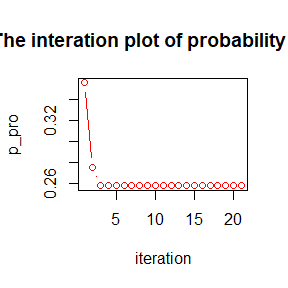

```r
plot(c(1:(counter-1)),p_pro[1:counter-1],xlab = "iteration",ylab='p_pro',type="b",col='red',main="The interation plot of probability of 'p'")
```

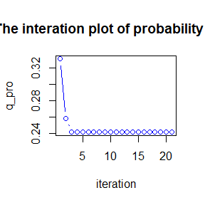

```r
plot(c(1:(counter-1)),q_pro[1:counter-1],xlab = "iteration",ylab='q_pro',type="b",col='blue',main="The interation plot of probability of 'q'")
```

## HW10

Question:

1. Use both for loops and lapply() to fit linear models to the mtcars using the formulas stored in this list: formulas <- list( mpg ~ disp, mpg ~ I(1 / disp), mpg ~ disp + wt, mpg ~ I(1 / disp) + wt )
2. Fit the model mpg ~ disp to each of the bootstrap replicates of mtcars in the list below by using a for loop and lapply(). Can you do it without an anonymous function?

bootstraps <- lapply(1:10, function(i) { rows <- sample(1:nrow(mtcars), rep = TRUE) mtcars[rows, ] })

```r
formulas <- list(
mpg ~ disp,
mpg ~ I(1 / disp),
mpg ~ disp + wt,
mpg ~ I(1 / disp) + wt
)
## loop
for (i in seq_along(formulas)) {
    lm(formulas[[i]],data=mtcars)
}
```

```r
bootstraps <- lapply(1:10, function(i){
  rows <- sample(1:nrow(mtcars), rep = TRUE)
  mtcars[rows, ]
  })
## loop

for (i in seq_along(bootstraps)) {
  lm(mpg~disp,data = bootstraps[[i]])
}
```

```r
rsq <- function(mod) summary(mod)$r.squared
## EX.3
result_EX.3<-lapply(lapply(formulas,function(x){lm(formula = x,data=mtcars)})
,rsq)
## EX.4
result_EX.4<-lapply(lapply(bootstraps,function(x){lm(mpg~disp,x)}),rsq)




## cleaning data
## show the result
result_EX.3<-as.numeric(result_EX.3)
result_EX.4<-as.numeric(result_EX.4)
lable_EX.3<-c("R^2_formula_1","R^2_formula_2","R^2_formula_3","R^2_formula_4")
lable_EX.4<-c("Result_1","Result_2","Result_3","Result_4","Result_5","Result_6","Result_7","Result_8","Result_9","Result_10")
data.frame(lable_EX.3,result_EX.3)
```

```
##      lable_EX.3 result_EX.3
## 1 R^2_formula_1   0.7183433
## 2 R^2_formula_2   0.8596865
## 3 R^2_formula_3   0.7809306
## 4 R^2_formula_4   0.8838038
```

```r
data.frame(lable_EX.4,result_EX.4)
```

```
##    lable_EX.4 result_EX.4
## 1    Result_1   0.8105921
## 2    Result_2   0.6828181
## 3    Result_3   0.9006993
## 4    Result_4   0.6276871
## 5    Result_5   0.7359473
## 6    Result_6   0.5719216
## 7    Result_7   0.7374696
## 8    Result_8   0.7210201
## 9    Result_9   0.6463818
## 10  Result_10   0.7159902
```

```r
## an anonymous function
p.value <- function(mod) mod$p.value
## t-test for 100 times
trials <- replicate(100,t.test(rpois(10, 10), rpois(7, 10)),simplify = FALSE)
## use sapply to extract p_value
p_value1<-sapply(trials,p.value)
```

## HW11

Question: (1) You have already written an R function for Exercise 9.4 (page 277, Statistical Computing with R). Rewrite an Rcpp function for the same task.

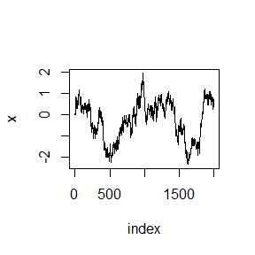

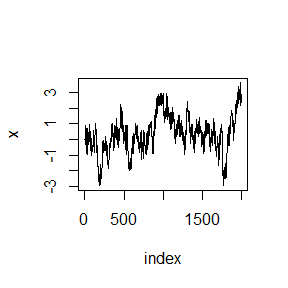

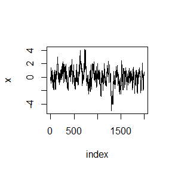

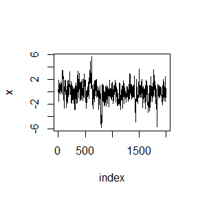

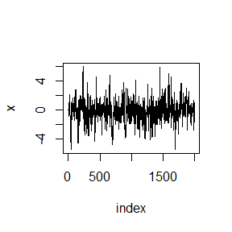

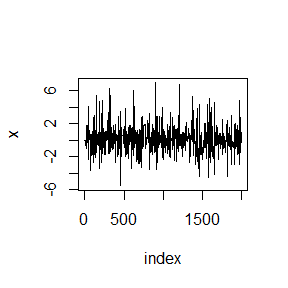

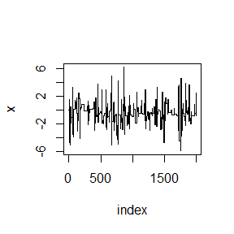

```r
# This is the Rcpp file
# insert the cpp
library(Rcpp)
Rcpp::sourceCpp('C:/Users/YE/Desktop/StatisticalComputing/homework/HW11/randomwalk.cpp')

# define the function to compare

for (i in 1:length(sigma)) {
  x<-RandomWalk_Cpp(sigma[i])
  plot(index,x,type = "l",main = ,ylab = "x")
}
```